# Return Home

[View Code on Github](https://github.com/JohnKimaiyo/Business-Analytics-Power-BI/blob/main/Projects/Webscraping%20Projects/Top%20USA%20Podcast%20YouTube%20Channels.ipynb)

# Top USA Podcast YouTube Channels

## 1 Lex Fridman

Lex Fridman is a Russian-American computer scientist and podcaster. He hosts the Lex Fridman Podcast, in which he interviews guests, which have included prominent figures in various fields, including science, technology, sports, and politics.

## 2 Theo Von

Theodor Capitani von Kurnatowski III, known professionally as Theo Von, is an American stand-up comedian, podcaster, actor, and former reality television personality. He is the host of the This Past Weekend podcast and former co-host of The King and the Sting podcast with Brendan Schaub.

## 4 The Diary of a CEO

A few years ago I was a broke, university dropout, at 18 I built an industry leading social media marketing company, and at 27 I resigned as CEO.

## 5 FLAGRANT

Flagrant is a comedy podcast that delivers unfiltered, unapologetic, and unruly hot takes directly to your dome piece.

## 6 PDB Podcast

The PBD Podcast is a podcast that discusses, current events, trending topics and politics as they relate to life and business. Stay tuned for new episodes and guest appearances.

## 7 YMH Studios

Videos from YMH Studios podcasts "Your Mom's House" with Tom Segura and Christina Pazsitzky, “2 Bears, 1 Cave” with Tom Segura and Bert Kreischer, "First Date" with Lauren Compton, "The Danny Brown Show" with Danny Brown, and "Not Today, Pal" with Robert Iler and Jamie-Lynn Sigler.

## 8 VladTv

Exclusive, hard-hitting interviews with rappers, singers, actors, basketball players, football players, professional wrestlers, comedians, former criminals, activists, media personalities, business tycoons, models, producers, managers, lawyers, social media stars, doctors, book authors, and everyone in between. Updated daily.

```python
# lets import libraries
from googleapiclient.discovery import build
import pandas as pd
import seaborn as sns
import matplotlib.pyplot as plt
```

## 1 Lex Fridman

```python
#  Function to get Lex Fridman Youtube channel statistics

api_key = 'AIzaSyB24Kop04L1GlTgRCm1XtQ4KB2a4gaBOwA'
Lex_Fridman_channel_id = ['UCSHZKyawb77ixDdsGog4iWA' #  Lex Fridman

              ]
youtube = build('youtube','v3',developerKey = api_key)

from googleapiclient.errors import HttpError

def get_channel_stats(youtube, Lex_Fridman_channel_id):
    all_data = []
    try:
        request = youtube.channels().list(
            part='snippet,contentDetails,statistics',
            id=','.join(Lex_Fridman_channel_id)
        )
        response = request.execute()

        for item in response.get('items', []):
            snippet = item.get('snippet', {})
            statistics = item.get('statistics', {})

            data = {
                'Channel_name': snippet.get('title', ''),
                'Subscribers': statistics.get('subscriberCount', ''),
                'Views': statistics.get('viewCount', ''),
                'Total_videos': statistics.get('videoCount', '')
            }

            all_data.append(data)

    except HttpError as e:
        print(f"HTTP error occurred: {e}")
        print(f"Request URL: {e.resp.request.url}")
        print(f"Request body: {e.resp.request.body}")

    return all_data
```

```python
get_channel_stats(youtube,Lex_Fridman_channel_id)
```

```
[{'Channel_name': 'Lex Fridman',
  'Subscribers': '3580000',
  'Views': '582585116',
  'Total_videos': '793'}]
```

```python
channel_statistics = get_channel_stats(youtube,Lex_Fridman_channel_id )
```

```python
Lex_Fridman_channel_data =pd.DataFrame(channel_statistics)
```

```python
Lex_Fridman_channel_data
```

|  | Channel_name | Subscribers | Views | Total_videos |
| --- | --- | --- | --- | --- |
| 0 | Lex Fridman | 3580000 | 582585116 | 793 |

## 2 Theo Von

```python
#  Function to get   Theo Von Youtube channel statistics

api_key = 'AIzaSyB24Kop04L1GlTgRCm1XtQ4KB2a4gaBOwA'
Theo_Von_channel_id = ['UC5AQEUAwCh1sGDvkQtkDWUQ' #  Theo Von

              ]
youtube = build('youtube','v3',developerKey = api_key)

from googleapiclient.errors import HttpError

def get_channel_stats(youtube, Theo_Von_channel_id):
    all_data = []
    try:
        request = youtube.channels().list(
            part='snippet,contentDetails,statistics',
            id=','.join(Theo_Von_channel_id)
        )
        response = request.execute()

        for item in response.get('items', []):
            snippet = item.get('snippet', {})
            statistics = item.get('statistics', {})

            data = {
                'Channel_name': snippet.get('title', ''),
                'Subscribers': statistics.get('subscriberCount', ''),
                'Views': statistics.get('viewCount', ''),
                'Total_videos': statistics.get('videoCount', '')
            }

            all_data.append(data)

    except HttpError as e:
        print(f"HTTP error occurred: {e}")
        print(f"Request URL: {e.resp.request.url}")
        print(f"Request body: {e.resp.request.body}")

    return all_data
```

```python
get_channel_stats(youtube,Theo_Von_channel_id)
```

```
[{'Channel_name': 'Theo Von',
  'Subscribers': '2370000',
  'Views': '374799041',
  'Total_videos': '675'}]
```

```python
channel_statistics = get_channel_stats(youtube,Theo_Von_channel_id )
```

```python
Theo_Von_channel_data =pd.DataFrame(channel_statistics)
```

```python
Theo_Von_channel_data
```

|  | Channel_name | Subscribers | Views | Total_videos |
| --- | --- | --- | --- | --- |
| 0 | Theo Von | 2370000 | 374799041 | 675 |

## 3 TimCast

```python
#  Function to get  TimCast Youtube channel statistics

api_key = 'AIzaSyB24Kop04L1GlTgRCm1XtQ4KB2a4gaBOwA'
TimCast_channel_id = ['UCLwNTXWEjVd2qIHLcXxQWxA' #   TimCast

              ]
youtube = build('youtube','v3',developerKey = api_key)

from googleapiclient.errors import HttpError

def get_channel_stats(youtube, TimCast_channel_id):
    all_data = []
    try:
        request = youtube.channels().list(
            part='snippet,contentDetails,statistics',
            id=','.join(TimCast_channel_id)
        )
        response = request.execute()

        for item in response.get('items', []):
            snippet = item.get('snippet', {})
            statistics = item.get('statistics', {})

            data = {
                'Channel_name': snippet.get('title', ''),
                'Subscribers': statistics.get('subscriberCount', ''),
                'Views': statistics.get('viewCount', ''),
                'Total_videos': statistics.get('videoCount', '')
            }

            all_data.append(data)

    except HttpError as e:
        print(f"HTTP error occurred: {e}")
        print(f"Request URL: {e.resp.request.url}")
        print(f"Request body: {e.resp.request.body}")

    return all_data
```

```python
get_channel_stats(youtube,TimCast_channel_id)
```

```
[{'Channel_name': 'Timcast IRL',
  'Subscribers': '1620000',
  'Views': '1076098082',
  'Total_videos': '6370'}]
```

```python
channel_statistics = get_channel_stats(youtube,TimCast_channel_id )
```

```python
TimCast_channel_data =pd.DataFrame(channel_statistics)
```

```python
TimCast_channel_data
```

|  | Channel_name | Subscribers | Views | Total_videos |
| --- | --- | --- | --- | --- |
| 0 | Timcast IRL | 1620000 | 1076098082 | 6370 |

## 4 The Diary of a CEO

```python
#  Function to get  The Diary of a CEO Youtube channel statistics

api_key = 'AIzaSyB24Kop04L1GlTgRCm1XtQ4KB2a4gaBOwA'
The_Diary_of_a_CEO_channel_id = ['UCGq-a57w-aPwyi3pW7XLiHw' #  The Diary of a CEO

              ]
youtube = build('youtube','v3',developerKey = api_key)

from googleapiclient.errors import HttpError

def get_channel_stats(youtube, The_Diary_of_a_CEO_channel_id):
    all_data = []
    try:
        request = youtube.channels().list(
            part='snippet,contentDetails,statistics',
            id=','.join(The_Diary_of_a_CEO_channel_id)
        )
        response = request.execute()

        for item in response.get('items', []):
            snippet = item.get('snippet', {})
            statistics = item.get('statistics', {})

            data = {
                'Channel_name': snippet.get('title', ''),
                'Subscribers': statistics.get('subscriberCount', ''),
                'Views': statistics.get('viewCount', ''),
                'Total_videos': statistics.get('videoCount', '')
            }

            all_data.append(data)

    except HttpError as e:
        print(f"HTTP error occurred: {e}")
        print(f"Request URL: {e.resp.request.url}")
        print(f"Request body: {e.resp.request.body}")

    return all_data
```

```python
get_channel_stats(youtube,The_Diary_of_a_CEO_channel_id)
```

```
[{'Channel_name': 'The Diary Of A CEO',
  'Subscribers': '4860000',
  'Views': '291280650',
  'Total_videos': '261'}]
```

```python
channel_statistics = get_channel_stats(youtube,The_Diary_of_a_CEO_channel_id )
```

```python
The_Diary_of_a_CEO_channel_data =pd.DataFrame(channel_statistics)
```

```python
The_Diary_of_a_CEO_channel_data
```

|  | Channel_name | Subscribers | Views | Total_videos |
| --- | --- | --- | --- | --- |
| 0 | The Diary Of A CEO | 4860000 | 291280650 | 261 |

## 5 FLAGRANT

```python
#  Function to get  FLAGRANT  Youtube channel statistics

api_key = 'AIzaSyB24Kop04L1GlTgRCm1XtQ4KB2a4gaBOwA'
FLAGRANT_channel_id = ['UC5PstSsGrRwj2o6asQpC4Rg' #  FLAGRANT

              ]
youtube = build('youtube','v3',developerKey = api_key)

from googleapiclient.errors import HttpError

def get_channel_stats(youtube,FLAGRANT_channel_id):
    all_data = []
    try:
        request = youtube.channels().list(
            part='snippet,contentDetails,statistics',
            id=','.join(FLAGRANT_channel_id)
        )
        response = request.execute()

        for item in response.get('items', []):
            snippet = item.get('snippet', {})
            statistics = item.get('statistics', {})

            data = {
                'Channel_name': snippet.get('title', ''),
                'Subscribers': statistics.get('subscriberCount', ''),
                'Views': statistics.get('viewCount', ''),
                'Total_videos': statistics.get('videoCount', '')
            }

            all_data.append(data)

    except HttpError as e:
        print(f"HTTP error occurred: {e}")
        print(f"Request URL: {e.resp.request.url}")
        print(f"Request body: {e.resp.request.body}")

    return all_data
```

```python
get_channel_stats(youtube,FLAGRANT_channel_id)
```

```
[{'Channel_name': 'FLAGRANT',
  'Subscribers': '1530000',
  'Views': '354549135',
  'Total_videos': '458'}]
```

```python
channel_statistics = get_channel_stats(youtube,FLAGRANT_channel_id )
```

```python
FLAGRANT_channel_data =pd.DataFrame(channel_statistics)
```

```python
FLAGRANT_channel_data
```

|  | Channel_name | Subscribers | Views | Total_videos |
| --- | --- | --- | --- | --- |
| 0 | FLAGRANT | 1530000 | 354549135 | 458 |

## 6 PDB Podcast

```python
#  Function to get   PDB Podcast Youtube channel statistics

api_key = 'AIzaSyB24Kop04L1GlTgRCm1XtQ4KB2a4gaBOwA'
PDB_Podcast_channel_id = ['UCGX7nGXpz-CmO_Arg-cgJ7A' #  PDB Podcast

              ]
youtube = build('youtube','v3',developerKey = api_key)

from googleapiclient.errors import HttpError

def get_channel_stats(youtube, PDB_Podcast_channel_id):
    all_data = []
    try:
        request = youtube.channels().list(
            part='snippet,contentDetails,statistics',
            id=','.join(PDB_Podcast_channel_id)
        )
        response = request.execute()

        for item in response.get('items', []):
            snippet = item.get('snippet', {})
            statistics = item.get('statistics', {})

            data = {
                'Channel_name': snippet.get('title', ''),
                'Subscribers': statistics.get('subscriberCount', ''),
                'Views': statistics.get('viewCount', ''),
                'Total_videos': statistics.get('videoCount', '')
            }

            all_data.append(data)

    except HttpError as e:
        print(f"HTTP error occurred: {e}")
        print(f"Request URL: {e.resp.request.url}")
        print(f"Request body: {e.resp.request.body}")

    return all_data
```

```python
get_channel_stats(youtube,PDB_Podcast_channel_id)
```

```
[{'Channel_name': 'PBD Podcast',
  'Subscribers': '1600000',
  'Views': '267348904',
  'Total_videos': '1149'}]
```

```python
channel_statistics = get_channel_stats(youtube,PDB_Podcast_channel_id )
```

```python
PDB_Podcast_channel_data =pd.DataFrame(channel_statistics)
```

```python
PDB_Podcast_channel_data
```

|  | Channel_name | Subscribers | Views | Total_videos |
| --- | --- | --- | --- | --- |
| 0 | PBD Podcast | 1600000 | 267348904 | 1149 |

## 7 YMH Studios

```python
#  Function to get   YMH Studios Youtube channel statistics

api_key = 'AIzaSyB24Kop04L1GlTgRCm1XtQ4KB2a4gaBOwA'
YMH_Studios_channel_id = ['UCYIgiXwJck_Pb5Nj-wIrsqg' #  YMH Studios

              ]
youtube = build('youtube','v3',developerKey = api_key)

from googleapiclient.errors import HttpError

def get_channel_stats(youtube, YMH_Studios_channel_id):
    all_data = []
    try:
        request = youtube.channels().list(
            part='snippet,contentDetails,statistics',
            id=','.join(YMH_Studios_channel_id)
        )
        response = request.execute()

        for item in response.get('items', []):
            snippet = item.get('snippet', {})
            statistics = item.get('statistics', {})

            data = {
                'Channel_name': snippet.get('title', ''),
                'Subscribers': statistics.get('subscriberCount', ''),
                'Views': statistics.get('viewCount', ''),
                'Total_videos': statistics.get('videoCount', '')
            }

            all_data.append(data)

    except HttpError as e:
        print(f"HTTP error occurred: {e}")
        print(f"Request URL: {e.resp.request.url}")
        print(f"Request body: {e.resp.request.body}")

    return all_data
```

```python
get_channel_stats(youtube,YMH_Studios_channel_id )
```

```
[{'Channel_name': 'YMH Studios',
  'Subscribers': '1860000',
  'Views': '907072350',
  'Total_videos': '2633'}]
```

```python
channel_statistics = get_channel_stats(youtube,YMH_Studios_channel_id)
```

```python
YMH_Studios_channel_data =pd.DataFrame(channel_statistics)
```

```python
YMH_Studios_channel_data
```

|  | Channel_name | Subscribers | Views | Total_videos |
| --- | --- | --- | --- | --- |
| 0 | YMH Studios | 1860000 | 907072350 | 2633 |

## 8 VladTv

```python
#  Function to get    VladTv Youtube channel statistics

api_key = 'AIzaSyB24Kop04L1GlTgRCm1XtQ4KB2a4gaBOwA'
VladTv_channel_id = ['UCg7lal8IC-xPyKfgH4rdUcA' #  VladTv

              ]
youtube = build('youtube','v3',developerKey = api_key)

from googleapiclient.errors import HttpError

def get_channel_stats(youtube, VladTv_channel_id):
    all_data = []
    try:
        request = youtube.channels().list(
            part='snippet,contentDetails,statistics',
            id=','.join(VladTv_channel_id)
        )
        response = request.execute()

        for item in response.get('items', []):
            snippet = item.get('snippet', {})
            statistics = item.get('statistics', {})

            data = {
                'Channel_name': snippet.get('title', ''),
                'Subscribers': statistics.get('subscriberCount', ''),
                'Views': statistics.get('viewCount', ''),
                'Total_videos': statistics.get('videoCount', '')
            }

            all_data.append(data)

    except HttpError as e:
        print(f"HTTP error occurred: {e}")
        print(f"Request URL: {e.resp.request.url}")
        print(f"Request body: {e.resp.request.body}")

    return all_data
```

```python
get_channel_stats(youtube,VladTv_channel_id)
```

```
[{'Channel_name': 'djvlad',
  'Subscribers': '5740000',
  'Views': '5370479203',
  'Total_videos': '30163'}]
```

```python
channel_statistics = get_channel_stats(youtube,VladTv_channel_id )
```

```python
VladTv_channel_data =pd.DataFrame(channel_statistics)
```

```python
VladTv_channel_data
```

|  | Channel_name | Subscribers | Views | Total_videos |
| --- | --- | --- | --- | --- |
| 0 | djvlad | 5740000 | 5370479203 | 30163 |

```python
# Combine DataFrames using concat
combined_podcast_channels_df = pd.concat([
                                   Lex_Fridman_channel_data ,
                                      Theo_Von_channel_data,
                                       TimCast_channel_data,
                                       The_Diary_of_a_CEO_channel_data ,
                                       FLAGRANT_channel_data,
                                    PDB_Podcast_channel_data,
                                    YMH_Studios_channel_data,
                                      VladTv_channel_data,
                                      ], ignore_index=True)

# Display the result
print(combined_podcast_channels_df)
```

```
         Channel_name Subscribers       Views Total_videos
0         Lex Fridman     3580000   582585116          793
1            Theo Von     2370000   374799041          675
2         Timcast IRL     1620000  1076098082         6370
3  The Diary Of A CEO     4860000   291280650          261
4            FLAGRANT     1530000   354549135          458
5         PBD Podcast     1600000   267348904         1149
6         YMH Studios     1860000   907072350         2633
7              djvlad     5740000  5370479203        30163
```

```python
# lets change the datatypes to perform  visualisations
combined_podcast_channels_df['Subscribers'] = pd.to_numeric(combined_podcast_channels_df['Subscribers'])
combined_podcast_channels_df['Views'] = pd.to_numeric(combined_podcast_channels_df['Views'])
combined_podcast_channels_df['Total_videos'] = pd.to_numeric(combined_podcast_channels_df['Total_videos'])
# letsconirm if the datatypes has changed
combined_podcast_channels_df.info()
```

```
<class 'pandas.core.frame.DataFrame'>
RangeIndex: 8 entries, 0 to 7
Data columns (total 4 columns):
 #   Column        Non-Null Count  Dtype
---  ------        --------------  -----
 0   Channel_name  8 non-null      object
 1   Subscribers   8 non-null      int64
 2   Views         8 non-null      int64
 3   Total_videos  8 non-null      int64
dtypes: int64(3), object(1)
memory usage: 388.0+ bytes
```

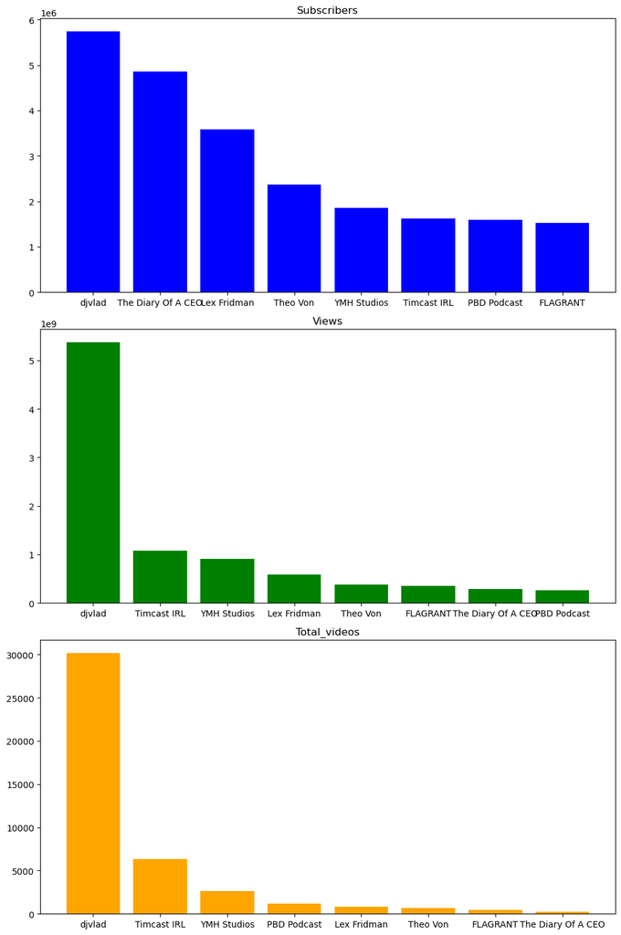

```python
import matplotlib.pyplot as plt

def plot_sorted_bar(df, column, color, ax):
    # Sort the DataFrame by the specified column in descending order
    df_sorted = df.sort_values(by=column, ascending=False)

    # Plotting the bar chart
    ax.bar(df_sorted['Channel_name'], df_sorted[column], color=color)
    ax.set_title(column.capitalize())  # Set the title with the capitalized column name

# Sort and plot Subscribers
fig, axes = plt.subplots(nrows=3, ncols=1, figsize=(10, 15))
plot_sorted_bar(combined_podcast_channels_df, 'Subscribers', 'blue', axes[0])

# Sort and plot Views
plot_sorted_bar(combined_podcast_channels_df, 'Views', 'green', axes[1])

# Sort and plot Total Videos
plot_sorted_bar(combined_podcast_channels_df, 'Total_videos', 'orange', axes[2])

# Adjust layout for better visibility
plt.tight_layout()

# Show the plot
plt.show()
```